# Titanic exercise

# 1 Titanic Dataset Description

This document details the analysis of the famous Titanic dataset, a popular choice for introductory data science projects. The dataset contains information about passengers aboard the RMS Titanic, including whether they survived the disaster.

## 1.1 Dataset Overview

```r
titanic_train <- read_csv("data/titanic/train.csv")
kable(head(titanic_train))%>%
  kable_styling(latex_options = "scale_down")%>%
  landscape()
```

| PassengerId | Survived | Pclass | Name | Sex | Age | SibSp | Parch | Ticket | Fare | Cabin | Embarked |
| --- | --- | --- | --- | --- | --- | --- | --- | --- | --- | --- | --- |
| 1 | 0 | 3 | Braund, Mr. Owen Harris | male | 22 | 1 | 0 | A/5 21171 | 7.2500 | NA | S |
| 2 | 1 | 1 | Cumings, Mrs. John Bradley (Florence Briggs Thayer) | female | 38 | 1 | 0 | PC 17599 | 71.2833 | C85 | C |
| 3 | 1 | 3 | Heikkinen, Miss. Laina | female | 26 | 0 | 0 | STON/O2. 3101282 | 7.9250 | NA | S |
| 4 | 1 | 1 | Futrelle, Mrs. Jacques Heath (Lily May Peel) | female | 35 | 1 | 0 | 113803 | 53.1000 | C123 | S |
| 5 | 0 | 3 | Allen, Mr. William Henry | male | 35 | 0 | 0 | 373450 | 8.0500 | NA | S |
| 6 | 0 | 3 | Moran, Mr. James | male | NA | 0 | 0 | 330877 | 8.4583 | NA | Q |

```r
as.data.frame(report(titanic_train))
```

```
Variable    | n_Obs | percentage_Missing | n_Entries | n_Missing |   Mean |     SD | Median |    MAD |  Min |    Max | Skewness | Kurtosis
------------------------------------------------------------------------------------------------------------------------------------------
PassengerId |   891 |               0.00 |           |           | 446.00 | 257.35 | 446.00 | 330.62 | 1.00 | 891.00 |     0.00 |    -1.20
Survived    |   891 |               0.00 |           |           |   0.38 |   0.49 |   0.00 |   0.00 | 0.00 |   1.00 |     0.48 |    -1.78
Pclass      |   891 |               0.00 |           |           |   2.31 |   0.84 |   3.00 |   0.00 | 1.00 |   3.00 |    -0.63 |    -1.28
Name        |   891 |               0.00 |    891.00 |         0 |        |        |        |        |      |        |          |
Sex         |   891 |               0.00 |      2.00 |         0 |        |        |        |        |      |        |          |
Age         |   891 |              19.87 |           |           |  29.70 |  14.53 |        |  13.34 | 0.42 |  80.00 |     0.39 |     0.18
SibSp       |   891 |               0.00 |           |           |   0.52 |   1.10 |   0.00 |   0.00 | 0.00 |   8.00 |     3.70 |    17.88
Parch       |   891 |               0.00 |           |           |   0.38 |   0.81 |   0.00 |   0.00 | 0.00 |   6.00 |     2.75 |     9.78
Ticket      |   891 |               0.00 |    681.00 |         0 |        |        |        |        |      |        |          |
Fare        |   891 |               0.00 |           |           |  32.20 |  49.69 |  14.45 |  10.24 | 0.00 | 512.33 |     4.79 |    33.40
Cabin       |   891 |              77.10 |    147.00 |       687 |        |        |        |        |      |        |          |
Embarked    |   891 |               0.22 |      3.00 |         2 |        |        |        |        |      |        |          |
```

```r
titanic_test <- read_csv("data/titanic/test.csv")
kable(head(titanic_test))%>%
  kable_styling(latex_options = "scale_down")%>%
  landscape()
```

| PassengerId | Pclass | Name | Sex | Age | SibSp | Parch | Ticket | Fare | Cabin | Embarked |
| --- | --- | --- | --- | --- | --- | --- | --- | --- | --- | --- |
| 892 | 3 | Kelly, Mr. James | male | 34.5 | 0 | 0 | 330911 | 7.8292 | NA | Q |
| 893 | 3 | Wilkes, Mrs. James (Ellen Needs) | female | 47.0 | 1 | 0 | 363272 | 7.0000 | NA | S |
| 894 | 2 | Myles, Mr. Thomas Francis | male | 62.0 | 0 | 0 | 240276 | 9.6875 | NA | Q |
| 895 | 3 | Wirz, Mr. Albert | male | 27.0 | 0 | 0 | 315154 | 8.6625 | NA | S |
| 896 | 3 | Hirvonen, Mrs. Alexander (Helga E Lindqvist) | female | 22.0 | 1 | 1 | 3101298 | 12.2875 | NA | S |
| 897 | 3 | Svensson, Mr. Johan Cervin | male | 14.0 | 0 | 0 | 7538 | 9.2250 | NA | S |

```r
as.data.frame(report(titanic_test))
```

```
Variable    | n_Obs | percentage_Missing | n_Entries | n_Missing |    Mean |     SD |  Median |    MAD |    Min |     Max | Skewness | Kurtosis
-----------------------------------------------------------------------------------------------------------------------------------------------
PassengerId |   418 |               0.00 |           |           | 1100.50 | 120.81 | 1100.50 | 154.93 | 892.00 | 1309.00 |     0.00 |    -1.20
Pclass      |   418 |               0.00 |           |           |    2.27 |   0.84 |    3.00 |   0.00 |   1.00 |    3.00 |    -0.53 |    -1.38
Name        |   418 |               0.00 |    418.00 |         0 |         |        |         |        |        |         |          |
Sex         |   418 |               0.00 |      2.00 |         0 |         |        |         |        |        |         |          |
Age         |   418 |              20.57 |           |           |   30.27 |  14.18 |         |  11.86 |   0.17 |   76.00 |     0.46 |     0.08
SibSp       |   418 |               0.00 |           |           |    0.45 |   0.90 |    0.00 |   0.00 |   0.00 |    8.00 |     4.17 |    26.50
Parch       |   418 |               0.00 |           |           |    0.39 |   0.98 |    0.00 |   0.00 |   0.00 |    9.00 |     4.65 |    31.41
Ticket      |   418 |               0.00 |    363.00 |         0 |         |        |         |        |        |         |          |
Fare        |   418 |               0.24 |           |           |   35.63 |  55.91 |         |  10.12 |   0.00 |  512.33 |     3.69 |    17.92
Cabin       |   418 |              78.23 |     76.00 |       327 |         |        |         |        |        |         |          |
Embarked    |   418 |               0.00 |      3.00 |         0 |         |        |         |        |        |         |          |
```

```r
#the Test dataset from kaggel does not come with the survival data, so we need to find it in another dataset and match.
titanic_complete <- titanic_complete <- read_delim("data/titanic/titanic_complete.csv",
    delim = ";", escape_double = FALSE, trim_ws = TRUE)

titanic_test <- titanic_test %>% left_join(titanic_complete %>% select(name, ticket, survived), by = c('Name'='name','Ticket'='ticket')) %>%
  rename(Survived = survived)

kable(head(titanic_test))%>%
  kable_styling(latex_options = "scale_down")%>%
  landscape()
```

| PassengerId | Pclass | Name | Sex | Age | SibSp | Parch | Ticket | Fare | Cabin | Embarked | Survived |
| --- | --- | --- | --- | --- | --- | --- | --- | --- | --- | --- | --- |
| 892 | 3 | Kelly, Mr. James | male | 34.5 | 0 | 0 | 330911 | 7.8292 | NA | Q | 0 |
| 893 | 3 | Wilkes, Mrs. James (Ellen Needs) | female | 47.0 | 1 | 0 | 363272 | 7.0000 | NA | S | 1 |
| 894 | 2 | Myles, Mr. Thomas Francis | male | 62.0 | 0 | 0 | 240276 | 9.6875 | NA | Q | 0 |
| 895 | 3 | Wirz, Mr. Albert | male | 27.0 | 0 | 0 | 315154 | 8.6625 | NA | S | 0 |
| 896 | 3 | Hirvonen, Mrs. Alexander (Helga E Lindqvist) | female | 22.0 | 1 | 1 | 3101298 | 12.2875 | NA | S | 1 |
| 897 | 3 | Svensson, Mr. Johan Cervin | male | 14.0 | 0 | 0 | 7538 | 9.2250 | NA | S | 1 |

```r
as.data.frame(report(titanic_test))
```

```
Variable    | n_Obs | percentage_Missing |    Mean |     SD |  Median |    MAD |    Min |     Max | Skewness | Kurtosis | n_Entries | n_Missing
-----------------------------------------------------------------------------------------------------------------------------------------------
PassengerId |   418 |               0.00 | 1100.50 | 120.81 | 1100.50 | 154.93 | 892.00 | 1309.00 |     0.00 |    -1.20 |           |
Pclass      |   418 |               0.00 |    2.27 |   0.84 |    3.00 |   0.00 |   1.00 |    3.00 |    -0.53 |    -1.38 |           |
Name        |   418 |               0.00 |         |        |         |        |        |         |          |          |    418.00 |         0
Sex         |   418 |               0.00 |         |        |         |        |        |         |          |          |      2.00 |         0
Age         |   418 |              20.57 |   30.27 |  14.18 |         |  11.86 |   0.17 |   76.00 |     0.46 |     0.08 |           |
SibSp       |   418 |               0.00 |    0.45 |   0.90 |    0.00 |   0.00 |   0.00 |    8.00 |     4.17 |    26.50 |           |
Parch       |   418 |               0.00 |    0.39 |   0.98 |    0.00 |   0.00 |   0.00 |    9.00 |     4.65 |    31.41 |           |
Ticket      |   418 |               0.00 |         |        |         |        |        |         |          |          |    363.00 |         0
Fare        |   418 |               0.24 |   35.63 |  55.91 |         |  10.12 |   0.00 |  512.33 |     3.69 |    17.92 |           |
Cabin       |   418 |              78.23 |         |        |         |        |        |         |          |          |     76.00 |       327
Embarked    |   418 |               0.00 |         |        |         |        |        |         |          |          |      3.00 |         0
Survived    |   418 |               5.26 |    0.37 |   0.48 |         |   0.00 |   0.00 |    1.00 |     0.55 |    -1.71 |           |
```

The dataset is typically split into two main files: `train.csv` and `test.csv`. * **`train.csv`**: Contains a set of passengers for whom the survival outcome (`Survived`) is provided. This is the dataset we will primarily use for exploratory data analysis (EDA), cleaning, feature engineering, and model training. * **`test.csv`**: Contains a similar set of passenger information but *without* the `Survived` column. In a typical Kaggle competition scenario, you would predict survival for these passengers. For this analysis, we will focus on understanding and modeling the `train.csv` data.

The goal of analyzing this dataset is to predict which passengers survived the Titanic shipwreck based on various features like age, gender, passenger class, and more.

## 1.2 Column Descriptions

Here’s a detailed description of each column (feature) present in the `train.csv` dataset:

| Column Name | Description | Data Type | Notes |
| --- | --- | --- | --- |
| `PassengerId` | A unique identifier for each passenger. | Integer | Used to identify rows; typically not used as a feature for modeling. |
| `Survived` | Survival status (our target variable). | Integer (0 or 1) | `0 = No` (Did not survive), `1 = Yes` (Survived) |
| `Pclass` | Passenger Class. A proxy for socio-economic status. | Integer (1, 2, 3) | `1 = 1st Class`, `2 = 2nd Class`, `3 = 3rd Class` |
| `Name` | Passenger’s name. | String | Can be used to extract titles (Mr., Mrs., Miss, Master, etc.) |
| `Sex` | Passenger’s gender. | String | `male` or `female` |
| `Age` | Age of the passenger in years. | Float | Has missing values. |
| `SibSp` | Number of siblings/spouses aboard the Titanic. | Integer | `SibSp` (Sibling/Spouse) |
| `Parch` | Number of parents/children aboard the Titanic. | Integer | `Parch` (Parent/Child) |
| `Ticket` | Ticket number. | String | Often contains alphanumeric characters. |
| `Fare` | Passenger fare. | Float | The cost of the ticket. |
| `Cabin` | Cabin number. | String | Many missing values. The first letter often indicates the deck. |
| `Embarked` | Port of embarkation. | String | `C = Cherbourg`, `Q = Queenstown`, `S = Southampton`. Has a few missing values. |

Understanding these features is the first crucial step in preparing the data for analysis and building predictive models.

## 1.3 visualizing the data

Other useful thing we can do to understand the data before any further analysis is to visualize it. As an example we are going to plot the Sex and Age in a graph for the two possible target values.

```r
table(titanic_train$Survived,titanic_train$Sex)
```

```
    female male
  0     81  468
  1    233  109
```

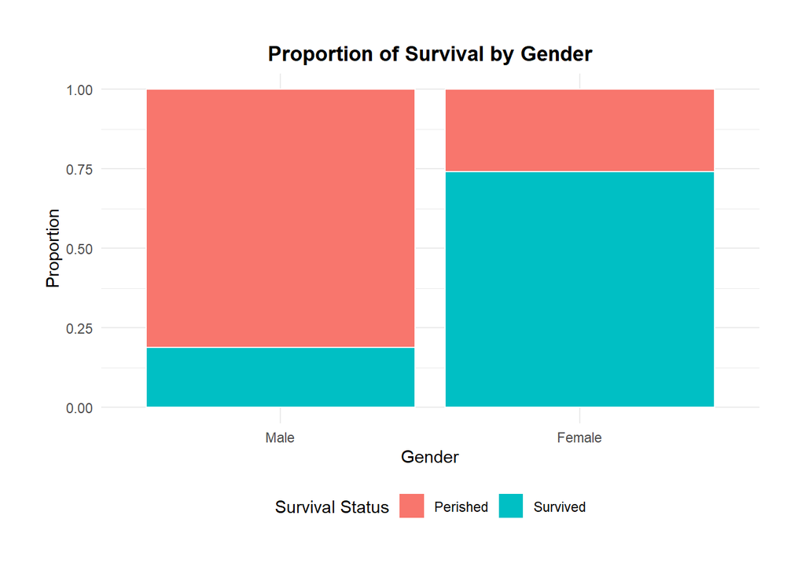

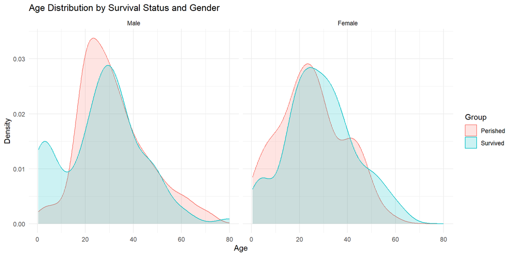

[output not shown]

[output cut: 240 more lines]

[output not shown]

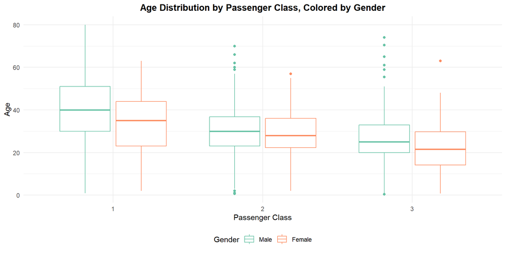

## 1.4 Handling missing values

Some of the fields have nulls. Based on our experience with the data we will decide on what to do with those. A common way of dealing with nulls is to assign the nulls to the most common class in their category, or the mean if it is a numerical value.

Embarked has only 2 missing values, so we can probably just fill in those blanks with the most frequent category, in this case S

```r
table(titanic_train$Embarked)
```

```
  C   Q   S
168  77 644
```

```r
titanic_train_processed <- titanic_train #let's reset our working dataset to the original version

#this will assing the most frequent value to the missing Embarked rows.
titanic_train_processed<- titanic_train_processed %>%
  mutate(Embarked = ifelse(is.na(Embarked),
         names(sort(table(Embarked), decreasing = TRUE))[1], Embarked))

table(titanic_train_processed$Embarked)
```

```
  C   Q   S
168  77 646
```

Cabin has 687 out of 891 missing values, so it does not look like a good decision to do this generalization here. We are going to drop the full field.

```r
titanic_train_processed <- titanic_train_processed %>% select (-c('Cabin'))
```

For age, we are going to assign the average age by sex for the missing values

```r
sum(is.na(titanic_train_processed$Age))
```

```
[1] 177
```

```r
titanic_train_processed <- titanic_train_processed %>%
group_by(Sex) %>%
  mutate(Age = ifelse(is.na(Age), mean(Age, na.rm = TRUE), Age)) %>%
  ungroup()

sum(is.na(titanic_train_processed$Age))
```

```
[1] 0
```

# 2 Selecting the important features.

The first thing that we notice is that there are numerical and categorical variables in the dataset.

There are some variables (features) that will not add any predictive value. For example Passenger Id is a unique value for each passenger, so it will not show any correlation between them. We can also assume that the name will not have any value to predict the survival. We will drop Name, PassengerId and Ticket

```r
titanic_train_processed <- titanic_train_processed %>% select (-c('Ticket', 'PassengerId', 'Name'))
```

## 2.1 Feature encoding

We can calculate the correlation between the variables to help with selecting the important ones.

The `cor()` function in R (and correlation functions in other languages) calculates the Pearson correlation coefficient, which is designed for numerical variables.

```r
# Select only numerical columns for correlation analysis

numerical_data <- titanic_train_processed %>%
  select(c('Survived', 'Pclass', 'Age', 'SibSp', 'Parch', 'Fare'))

kable (head(numerical_data))
```

| Survived | Pclass | Age | SibSp | Parch | Fare |
| --- | --- | --- | --- | --- | --- |
| 0 | 3 | 22.00000 | 1 | 0 | 7.2500 |
| 1 | 1 | 38.00000 | 1 | 0 | 71.2833 |
| 1 | 3 | 26.00000 | 0 | 0 | 7.9250 |
| 1 | 1 | 35.00000 | 1 | 0 | 53.1000 |
| 0 | 3 | 35.00000 | 0 | 0 | 8.0500 |
| 0 | 3 | 30.72664 | 0 | 0 | 8.4583 |

```r
correlation_matrix <- cor(numerical_data)

kable(correlation_matrix)
```

|  | Survived | Pclass | Age | SibSp | Parch | Fare |
| --- | --- | --- | --- | --- | --- | --- |
| Survived | 1.0000000 | -0.3384810 | -0.0804534 | -0.0353225 | 0.0816294 | 0.2573065 |
| Pclass | -0.3384810 | 1.0000000 | -0.3303908 | 0.0830814 | 0.0184427 | -0.5494996 |
| Age | -0.0804534 | -0.3303908 | 1.0000000 | -0.2369200 | -0.1825564 | 0.0890791 |
| SibSp | -0.0353225 | 0.0830814 | -0.2369200 | 1.0000000 | 0.4148377 | 0.1596510 |
| Parch | 0.0816294 | 0.0184427 | -0.1825564 | 0.4148377 | 1.0000000 | 0.2162249 |
| Fare | 0.2573065 | -0.5494996 | 0.0890791 | 0.1596510 | 0.2162249 | 1.0000000 |

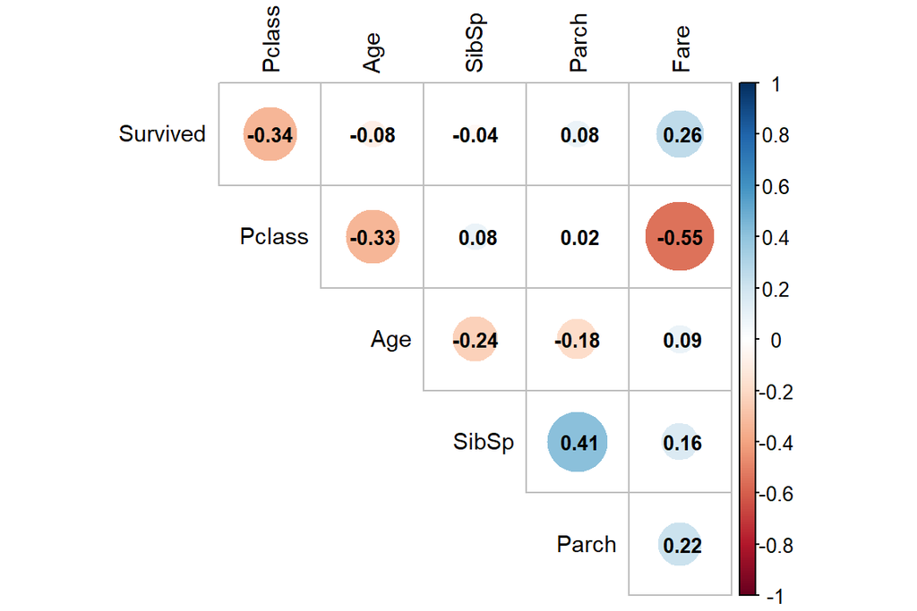

```r
# Create the correlation plot
# 'number' displays the correlation coefficients
# 'col' sets the color palette
# 'diag=FALSE' removes numbers on the diagonal
corrplot::corrplot(correlation_matrix,
                   method = "circle", # Can be "circle", "square", "ellipse", "number", "shade", "color", "pie"
                   type = "upper",   # Show only the upper triangle
                   tl.col = "black", # Color of text labels
                   addCoef.col = "black", # Add coefficients to the plot
                   number.cex = 0.8, # Size of the coefficients
                   tl.cex = 0.9,     # Size of the labels
                   diag = FALSE # Do not show correlation of a variable with itself
                   )
```

```r
rm(numerical_data)
```

To include categorical variables in such a matrix, you need to transform them into a numerical format. This has some benefits:

**Comprehensive View**: It allows you to see the linear relationships between all your numerical and relevant categorical features in one single matrix, providing a more holistic view of the dataset’s structure. **Insights into Categorical Predictors**: You can directly quantify how strong the linear relationship is between a categorical variable (e.g., ‘Sex’) and your target variable (‘Survived’), or other numerical features. **Preparation for Modeling**: This is a standard preprocessing step for many linear models (like linear regression or logistic regression) where categorical predictors need to be numeric.

Considerations:

- While useful, interpreting correlations involving dummy variables (especially for multi-level ones) requires care. A high correlation with one dummy variable (e.g., Embarked_C) doesn’t necessarily mean a high correlation with the overall ‘Embarked’ variable, but rather with that specific category compared to the reference group.
- Effect of Multi-collinearity: If you include all dummy variables for a multi-level categorical feature, it can introduce perfect multicollinearity, which some statistical tools might struggle with (though cor() will still compute it). This is why one dummy variable is usually dropped as a reference category in modeling, but for correlation, you might include all to see all pairwise relationships.

Processing:

- Binary Variables (like ‘Sex’): For a binary categorical variable (e.g., ‘Male’ and ‘Female’), you can convert it into a single dummy variable (e.g., Sex_Male where 1 = Male, 0 = Female, or vice-versa). The correlation coefficient between this dummy variable and another numerical variable is equivalent to a point-biserial correlation, which measures the relationship between a binary variable and a continuous one. This allows you to see how ‘Sex’ correlates with ‘Survived’, ‘Age’, ‘Fare’, etc.
- Multi-level Categorical Variables (like ‘Embarked’ or ‘Pclass’): For variables with more than two categories (e.g., ‘Embarked’ has C, Q, S), you would typically create a separate dummy variable for each category, minus one (to avoid multicollinearity). For instance, ‘Embarked’ could become Embarked_C, Embarked_Q, Embarked_S (dropping one as a reference). The correlation matrix would then show correlations of each of these dummy variables with other numerical features.

What is Multicollinearity?

Multicollinearity occurs in a regression model when two or more predictor variables are highly correlated with each other. In essence, one predictor variable can be linearly predicted from the others with a substantial degree of accuracy.

Why is Multicollinearity a Problem? While multicollinearity doesn’t usually affect the overall predictive power of a model, it can severely impact the interpretation of individual predictor variables:

- **Unreliable Coefficient Estimates**: The estimated regression coefficients for the correlated variables become unstable and difficult to interpret. Small changes in the data can lead to large changes in the coefficients, making it hard to determine the true effect of each variable.
- **Increased Standard Errors**: Multicollinearity inflates the standard errors of the coefficients, making them less statistically significant. This means you might incorrectly conclude that a variable is not important when it actually is.
- **Difficulty in Inferring Causality**: It becomes challenging to isolate the independent effect of each correlated predictor on the response variable.

*How Dummy Variables Cause Perfect Multicollinearity*: Consider a categorical variable like Sex with two levels: “Male” and “Female”. When you create dummy variables (also known as one-hot encoding):

You might create Sex_Male (1 if Male, 0 if Female) And Sex_Female (1 if Female, 0 if Male). If you include both Sex_Male and Sex_Female in a regression model, you introduce perfect multicollinearity, because Sex_Male and Sex_Female are perfectly negatively correlated. Knowing the value of one (e.g., Sex_Male = 1) immediately tells you the value of the other (Sex_Female = 0). They convey redundant information. In a linear equation, Sex_Female = 1 - Sex_Male.

This perfect linear relationship makes it impossible for the regression algorithm to uniquely estimate the coefficients for both variables.

Similarly, for Embark: If you have $k$ categories for a variable (e.g., Embarked_C, Embarked_Q, Embarked_S for C, Q, S), and you include all $k$ dummy variables along with an intercept term in your model, you create a perfect linear dependency. For any observation, $Embarked_C + Embarked_Q + Embarked_S = 1$. This makes it impossible for the model’s underlying matrix inversion (which is how coefficients are estimated) to yield a unique solution. This is known as the “dummy variable trap.”

The Solution: Dropping a Dummy Variable (Reference Category) To avoid perfect multicollinearity, the standard practice for regression modeling is to drop one of the dummy variables. The dropped category becomes the “reference category.”

If you keep Sex_Male and drop Sex_Female, the coefficient for Sex_Male will represent the difference in the outcome compared to the “Female” reference group (when Sex_Male is 0). Similarly, for ‘Embarked’ (C, Q, S), you’d create Embarked_C, Embarked_Q, and Embarked_S. To avoid multicollinearity, you’d drop one (e.g., Embarked_S), and the coefficients for Embarked_C and Embarked_Q would represent the difference compared to the “Southampton” reference group.

```r
# Select numerical columns and categorical columns to be dummified
titanic_train_dummies <- titanic_train_processed %>%
  # Convert Sex to factor for dummy_cols (if not already)
  mutate(
    #Survived = factor(Survived, levels = c(0, 1), labels = c("Perished", "Survived")),
    Sex = factor(Sex, levels = c("male", "female"), labels = c("Male", "Female")),
    Embarked = as.factor(Embarked)
  ) %>%
  # Create dummy variables for 'Sex' and 'Embarked'
  # .keep = "unused" removes the original columns that were dummified
  # remove_first_dummy = FALSE keeps all dummies to show all pairwise correlations
  fastDummies::dummy_cols(
    select_columns = c("Sex", "Embarked"),
    remove_first_dummy = FALSE,
    remove_selected_columns = TRUE
  )
kable(head(titanic_train_dummies))
```

| Survived | Pclass | Age | SibSp | Parch | Fare | Sex_Male | Sex_Female | Embarked_C | Embarked_Q | Embarked_S |
| --- | --- | --- | --- | --- | --- | --- | --- | --- | --- | --- |
| 0 | 3 | 22.00000 | 1 | 0 | 7.2500 | 1 | 0 | 0 | 0 | 1 |
| 1 | 1 | 38.00000 | 1 | 0 | 71.2833 | 0 | 1 | 1 | 0 | 0 |
| 1 | 3 | 26.00000 | 0 | 0 | 7.9250 | 0 | 1 | 0 | 0 | 1 |
| 1 | 1 | 35.00000 | 1 | 0 | 53.1000 | 0 | 1 | 0 | 0 | 1 |
| 0 | 3 | 35.00000 | 0 | 0 | 8.0500 | 1 | 0 | 0 | 0 | 1 |
| 0 | 3 | 30.72664 | 0 | 0 | 8.4583 | 1 | 0 | 0 | 1 | 0 |

In the code above, `remove_first_dummy = FALSE` is intentionally set. This is because:

- **Correlation vs. Regression:** While perfect multicollinearity is problematic for *estimating regression coefficients*, it’s not a direct issue for simply *calculating* a correlation matrix. The `cor()` function will still produce values.
- **Complete Pairwise Relationships:** By keeping all dummy variables, you get to see the pairwise correlation of each individual dummy (e.g., `Sex_Male`) with all other variables, which can still be informative for exploratory data analysis, even if you wouldn’t use all of them in a final regression model. For example, you can see the correlation between `Sex_Male` and `Survived`, and also between `Sex_Female` and `Survived` separately.

So, while dropping a dummy is crucial for building stable regression models, for the purpose of a purely descriptive correlation plot, including all dummy variables can sometimes offer more complete visual insights, provided you understand the underlying perfect collinearity between them.

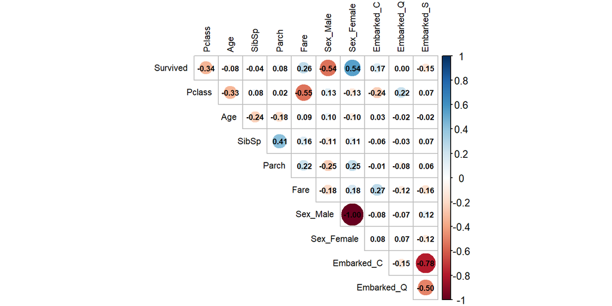

```r
# Calculate the correlation matrix
correlation_matrix <- cor(titanic_train_dummies)

# Create the correlation plot
corrplot::corrplot(correlation_matrix,
                   method = "circle", # Can be "circle", "square", "ellipse", "number", "shade", "color", "pie"
                   type = "upper",   # Show only the upper triangle
                   tl.col = "black", # Color of text labels
                   addCoef.col = "black", # Add coefficients to the plot
                   number.cex = 0.6, # Size of the coefficients (reduced for more variables)
                   tl.cex = 0.7,     # Size of the labels (reduced for more variables)
                   diag = FALSE,     # Do not show correlation of a variable with itself
                   #order = "hclust", # Optional: Order variables by hierarchical clustering
                   hclust.method = "complete" # Clustering method
                   )
```

## 2.2 Normalizing the numerical values

Normalizing numerical variables (also known as standardization when using methods like Z-score, which is `scale()` in R) is a very common preprocessing step in data analysis and machine learning). We need to do this for algorithms sensitive to scale.

Here’s why we often do it:

1. **Ensuring Fair Comparison (especially for algorithms sensitive to scale):**
- Many machine learning algorithms (like *K-Nearest Neighbors*, *Support Vector Machines*, *K-Means clustering*, or even regularization techniques in linear models) calculate distances between data points or rely on the magnitude of feature values.
- If features are on vastly different scales (e.g., ‘Age’ typically 0-80, ‘Fare’ potentially 0-500+), the feature with the larger scale can disproportionately influence the algorithm. ‘Fare’ might end up dominating the distance calculations simply because its values are numerically larger, even if ‘Age’ is equally or more important in reality. - Normalization brings all numerical features to a comparable scale, preventing features with larger numerical ranges from artificially dominating the analysis.
2. **Improving Algorithm Convergence and Performance:** - For optimization algorithms used in training models (e.g., *gradient descent* in neural networks or logistic regression), features on different scales can lead to “lopsided” cost functions that are harder and slower for the optimizer to converge on. Normalizing can create a more symmetrical and easier-to-navigate cost landscape, leading to faster and more stable model training.
3. **For Correlation Plots Specifically:** - While **Pearson correlation coefficients** themselves (`cor()` output) are **scale-invariant** (meaning the correlation value between two variables won’t change if you normalize one or both of them), normalizing the data *before* visualizing it can sometimes make the *visual representation* clearer, especially if you were using methods that plot the raw data points where scales matter.

However, the primary reason for including normalization *before* calculating the correlation matrix in our specific R code was often driven by the next step in a typical data analysis pipeline: preparing data for machine learning models where normalization *is* critical. By incorporating it early, we create a consistent `titanic_train_scaled` dataset that is ready for subsequent modeling steps.

In essence, normalization is a way to preprocess your data so that all numerical features contribute equally to the analysis, preventing biases introduced by their original scales and often leading to more robust and better-performing models.

We can use different methods for normalization. For example we can use z-score standardization:

```r
# Normalize numerical variables (Age, SibSp, Parch, Fare) using Z-score standardization
# Survived and Pclass are treated as discrete numerical variables, so usually not scaled for correlation.
# Sex_ and Embarked_ dummies are already 0/1.
titanic_train_scaled <- titanic_train_processed %>%
  mutate(     Age = scale(Age)[,1], # scale() returns a matrix, need to select the column     S
    ibSp = scale(SibSp)[,1],     Parch = scale(Parch)[,1],
    Fare = scale(Fare)[,1]
    # Pclass is technically numeric but represents categories; scaling might obscure its meaning
    # for correlation interpretation if its values 1,2,3 are seen as categories.
    # For now, we'll leave Pclass unscaled as it's often treated ordinally.
  )
kable(head(titanic_train_scaled))
```

| Survived | Pclass | Sex | Age | SibSp | Parch | Fare | Embarked | ibSp |
| --- | --- | --- | --- | --- | --- | --- | --- | --- |
| 0 | 3 | male | -0.5943984 | 1 | -0.4734077 | -0.5021631 | S | 0.4325504 |
| 1 | 1 | female | 0.6349621 | 1 | -0.4734077 | 0.7864036 | C | 0.4325504 |
| 1 | 3 | female | -0.2870583 | 0 | -0.4734077 | -0.4885799 | S | -0.4742788 |
| 1 | 1 | female | 0.4044570 | 1 | -0.4734077 | 0.4204941 | S | 0.4325504 |
| 0 | 3 | male | 0.4044570 | 0 | -0.4734077 | -0.4860644 | S | -0.4742788 |
| 0 | 3 | male | 0.0761136 | 0 | -0.4734077 | -0.4778481 | Q | -0.4742788 |

We can draw our correlation plot again and see that the normalization has not affected our coefficients:

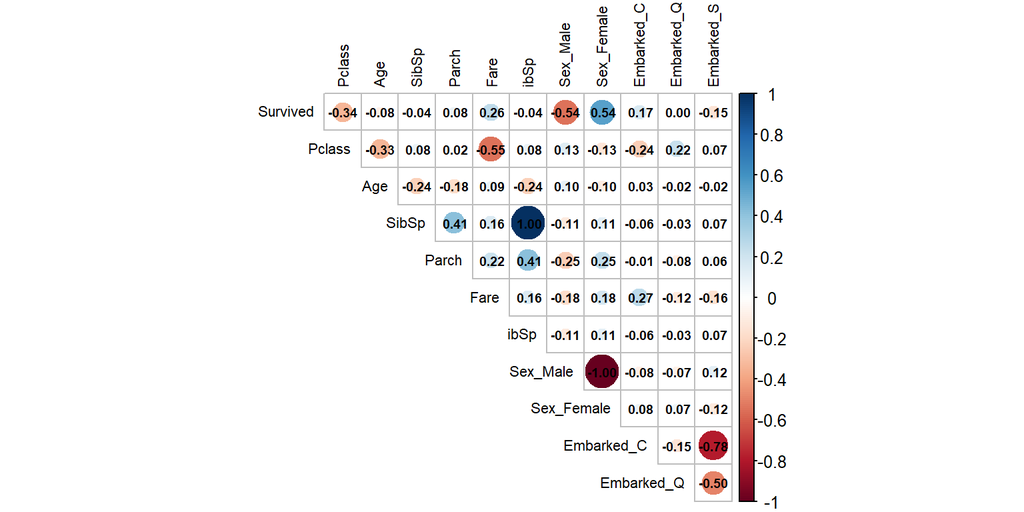

```r
titanic_train_dummies <- titanic_train_scaled %>%
  # Convert Sex to factor for dummy_cols (if not already)
  mutate(
    #Survived = factor(Survived, levels = c(0, 1), labels = c("Perished", "Survived")),
    Sex = factor(Sex, levels = c("male", "female"), labels = c("Male", "Female")),
    Embarked = as.factor(Embarked)
  ) %>%
  # Create dummy variables for 'Sex' and 'Embarked'
  # .keep = "unused" removes the original columns that were dummified
  # remove_first_dummy = FALSE keeps all dummies to show all pairwise correlations
  fastDummies::dummy_cols(
    select_columns = c("Sex", "Embarked"),
    remove_first_dummy = FALSE,
    remove_selected_columns = TRUE
  )
correlation_matrix <- cor(titanic_train_dummies )  # Create the correlation plot
corrplot::corrplot(correlation_matrix,
  method = "circle",
  type = "upper",
  tl.col = "black",
  addCoef.col = "black",
  number.cex = 0.6,
  tl.cex = 0.7,
  diag = FALSE,
  #order = "hclust",
  hclust.method = "complete" # Clustering method
  )
```

## 2.3 Normalization Techniques

When preparing data for modeling, especially for algorithms sensitive to feature scale, it’s important to normalize or standardize numerical variables. Below are several common techniques besides the z-score we just saw:

### 2.3.1 Min-Max Scaling

This rescales the feature to a fixed range, typically ([0, 1]):

$$x' = \frac{x - \min(x)}{\max(x) - \min(x)}$$

- **Use case**: Preserves the shape of the original distribution.
- **Sensitive to outliers**.

### 2.3.2 Robust Scaling

This method uses the median and interquartile range (IQR), making it robust to outliers:

$$x' = \frac{x - \text{median}(x)}{\text{IQR}(x)}$$

- **Use case**: When data contains outliers.
- **IQR** is the difference between the 75th and 25th percentiles.

### 2.3.3 Max Abs Scaling

Scales each feature by its maximum absolute value:

$$x' = \frac{x}{\max(|x|)}$$

- **Use case**: When data is already centered at zero.
- **Resulting range**: ([-1, 1])

### 2.3.4 Log Transformation

Useful for reducing right skewness in data:

$$x' = \log(x + 1)$$

- **Use case**: When data is highly skewed.
- **Note**: Adding 1 avoids issues with ((0)).

### 2.3.5 Box-Cox (for positive values only):

$$x' = \frac{x^\lambda - 1}{\lambda}, \quad \text{if } \lambda \ne 0$$

$$x' = \log(x), \quad \text{if } \lambda = 0$$

### 2.3.6 Yeo-Johnson (works with zero and negative values):

$$x' = \begin{cases} \frac{(x + 1)^\lambda - 1}{\lambda}, & x \ge 0, \lambda \ne 0 \\ \log(x + 1), & x \ge 0, \lambda = 0 \\ \frac{-(-x + 1)^{2 - \lambda} + 1}{2 - \lambda}, & x < 0, \lambda \ne 2 \\ -\log(-x + 1), & x < 0, \lambda = 2 \end{cases}$$

- **Use case**: When you want to normalize skewed data and make it more Gaussian.

Each method has its strengths depending on the data distribution and the model you’re using. Choose the one that best fits your use case.

Selecting the right technique for normalization is important depending on the method you are goint to use for feature selection: **Scaling affects feature distributions, which may in turn influence how statistical tests behave.** Here’s how this plays out:

- When Scaling Helps: For distance-based models (like k-NN or SVM), scaling ensures features are on similar ranges.
- It’s harmless when you’re using methods that rely purely on variance or entropy, like mutual information or correlation, provided the transformation doesn’t distort relationships.
- When Scaling Might Mislead: ANOVA and Chi-Square depend on the distribution shape. Transformations like log1p() alter skewness and variance. That can:
  - Make a feature look artificially more or less discriminative.
  - Violate assumptions of homogeneity of variances and normality, which ANOVA leans on.

`Log1p()` transformation alters the distribution of the data, which may leads us to think that we should only use it **after** feature selection to avoid those biases, but `log1p()` is often used precisely to normalize skewed data like Fare, which tends to follow a long-tail distribution. In fact, it might make the ANOVA more robust, not worse.

If you’re still uneasy or want to compare, try running ANOVA on both unscaled and scaled data to check if results diverge dramatically.

Consider visualizing distributions before and after transformation

We will see the results of each applied to the field Fare as an example:

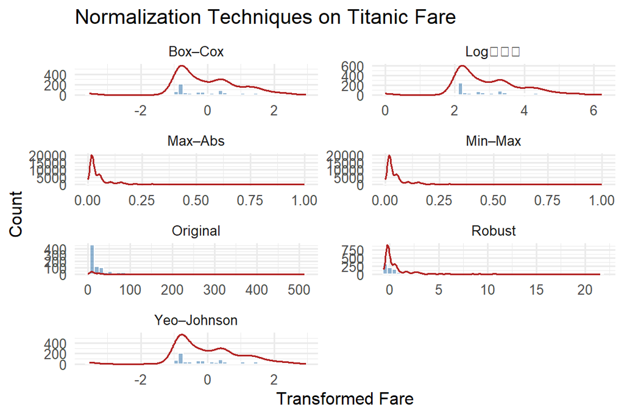

```r
library(bestNormalize)

# 2. Extract fare (replace NAs with 0)
fare <- titanic_train$Fare %>% replace_na(0)
# 3. Fit Box-Cox and Yeo-Johnson (they return objects; use predict())
bc_obj <- bestNormalize::boxcox(fare + 1)    # add 1 so that zero fares are valid
yj_obj <- bestNormalize::yeojohnson(fare)

# 4. Build a data.frame of all transforms
df_tall <- tibble(   Original   = fare,
  `Min–Max`  = (fare - min(fare)) / (max(fare) - min(fare)),
  Robust     = (fare - median(fare)) / IQR(fare),
  `Max–Abs`  = fare / max(abs(fare)),
  `Log₁ₚ₁`   = log1p(fare),    `Box–Cox`  = predict(bc_obj),
  `Yeo–Johnson` = predict(yj_obj) ) %>%
  pivot_longer(everything(),
    names_to = "Method",
    values_to = "Value")

ggplot(df_tall, aes(x = Value)) +
  geom_histogram(     bins  = 50,     fill  = "steelblue",     color = "white",     alpha = .6   ) +
  geom_density(     aes(y = after_stat(count)),      color = "firebrick",     size  = .7   ) +
  facet_wrap(~ Method, scales = "free", ncol = 2) +
  labs(     title = "Normalization Techniques on Titanic Fare",     x     = "Transformed Fare",     y     = "Count"   ) +
  theme_minimal(base_size = 12)
```

## 2.4 Feature selection Techniques

To enhance model performance and interpretability, we evaluate features in the Titanic dataset using four key selection methods:

- Correlation Coefficient,
- ANOVA,
- Chi-Square,
- Mutual Information.

Each technique brings a unique perspective depending on whether the feature is numerical or categorical and the nature of the response variable.

Before we continue, we are going to create again dummy variables but this time dropping one to avoid multicolinearity as explained.

We are starting again with the not normalized values, and we are going to use log transformation to Fare, and min-max to Age and Parch, and z-score to SibSp.

```r
# Select numerical columns and categorical columns to be dummified
titanic_train_dummies <- titanic_train_processed %>%
  mutate(Sex = factor(Sex, levels = c("male", "female"), labels = c("Male", "Female")),
    Embarked = as.factor(Embarked)) %>%
  fastDummies::dummy_cols(
    select_columns = c("Sex", "Embarked"),
    remove_first_dummy = TRUE,
    remove_selected_columns = TRUE
  )
titanic_train_scaled <- titanic_train_dummies %>%
  mutate(
    Age = (Age - min(Age)) / (max(Age) - min(Age)),
    SibSp = scale(SibSp)[,1], # scale() returns a matrix, need to select the column
    Parch = (Parch - min(Parch)) / (max(Parch) - min(Parch)),
    Fare =  log1p(Fare),
    # Pclass is technically numeric but represents categories; scaling might obscure its meaning
    # for correlation interpretation if its values 1,2,3 are seen as categories.
    # For now, we'll leave Pclass unscaled as it's often treated ordinally.
  )
```

### 2.4.1 Correlation Coefficient

The Pearson Correlation Coefficient measures linear association between continuous variables. It is defined as
$$r = \frac{\sum(x_i - \bar{x})(y_i - \bar{y})}{\sqrt{\sum(x_i - \bar{x})^2 \sum(y_i - \bar{y})^2}}$$
In our context, we apply it between continuous predictors and the binary outcome `survived`

```r
# Correlation of each feature with the target
correlation_matrix <- cor(titanic_train_scaled, use = "complete.obs")
correlation_matrix["Survived", ][-1]  # Drop self-correlation
```

```
      Pclass          Age        SibSp        Parch         Fare   Sex_Female
-0.338481036 -0.080453450 -0.035322499  0.081629407  0.329862129  0.543351381
  Embarked_Q   Embarked_S
 0.003650383 -0.149682723
```

#### Interpreting the results:

Note: Since Survived is binary, results are interpretable but not strictly Pearson-optimal.

What the Correlation Values Mean Value Range: Correlation coefficients range from -1 to +1.

- +1 indicates a perfect positive linear relationship.
- -1 indicates a perfect negative linear relationship.
- 0 means no linear relationship.

Direction:

A positive correlation (e.g. 0.4) with Survived suggests that as the feature increases, the probability of survival tends to increase.

A negative correlation (e.g. -0.3) implies that higher values of that feature are associated with lower survival probability.

Magnitude: Larger absolute values (closer to 1 or -1) show stronger linear relationships. However, anything under ±0.2 tends to be considered weak.

**Note**

Logistic regression models log-odds, not direct linear relationships—so correlation can guide but not fully capture predictive power.

Correlation only works on numeric variables. Categorical ones (like Sex, Pclass) need to be converted first or explored with Chi-Square or ANOVA.

Multicollinearity can be an issue if features are highly correlated with each other. That’s something to check before fitting your model.

### 2.4.2 ANOVA (Analysis of Variance)

(see ANOVA section in Linear Models)

ANOVA assesses whether the means of a numeric variable differ significantly across categories of a factor (e.g., Sex, Pclass).

The F-statistic formula is:
$$F = \frac{\text{Between-group variability}}{\text{Within-group variability}}$$

```r
#|layout-ncol: 2
# One-way ANOVA for each feature
anova_results <- sapply(names(titanic_train_scaled)[-1], function(var) {
  aov_formula <- as.formula(paste(var, "~ factor(Survived)"))
  summary(aov(aov_formula, data = titanic_train_scaled))[[1]][["Pr(>F)"]][1]
})

sort(anova_results)  # Features with smallest p-values are more significant
```

```
                                                                   Sex_Female
0.000000000000000000000000000000000000000000000000000000000000000000001406066
                                                                       Pclass
0.000000000000000000000000253704738797906380266995729488854749433812685310841
                                                                         Fare
0.000000000000000000000004646670286166910443775152073087042481347452849149704
                                                                   Embarked_S
0.000007223240983690352020815672595688283763593062758445739746093750000000000
                                                                        Parch
0.014799245374727624732780206784354959381744265556335449218750000000000000000
                                                                          Age
0.016304436741828617907223986094322754070162773132324218750000000000000000000
                                                                        SibSp
0.292243928698293353729553700759424827992916107177734375000000000000000000000
                                                                   Embarked_Q
0.913353235243424488309926800866378471255302429199218750000000000000000000000
```

```r
# Convert to a data frame for presentation
anova_df <- data.frame(
  Feature = names(anova_results),
  P_Value = round(anova_results, 5)  # Round for neatness
)

# Sort by p-value
anova_df <- anova_df[order(anova_df$P_Value), ]

# Display as a formatted table
knitr::kable(anova_df, format = "html", caption = "One-Way ANOVA P-values by Feature") %>%
  kable_styling(bootstrap_options = c("striped", "hover", "condensed"), full_width = F) %>%
  column_spec(1:ncol(anova_df), width = "400px")
```

One-Way ANOVA P-values by Feature

|  | Feature | P_Value |
| --- | --- | --- |
| Pclass | Pclass | 0.00000 |
| Fare | Fare | 0.00000 |
| Sex_Female | Sex_Female | 0.00000 |
| Embarked_S | Embarked_S | 0.00001 |
| Parch | Parch | 0.01480 |
| Age | Age | 0.01630 |
| SibSp | SibSp | 0.29224 |
| Embarked_Q | Embarked_Q | 0.91335 |

#### Interpreting One-Way ANOVA for Feature Selection

**Goal**: To see if the means of a numeric feature differ significantly between the groups (Survived = 0 vs. 1).

**Output Breakdown**

- The `Pr(>F)` value is the **p-value** for the F-test.
- A **low p-value** (typically < 0.05) means there’s a **statistically significant** difference in the feature’s distribution between survivors and non-survivors. **Significant Difference** → The feature likely has predictive power for survival.
- **High p-value** → The feature might not vary much between groups and could be less useful in your model.

Features with **smallest p-values** are most likely to provide separation between the classes. They’re your strongest contenders for logistic regression.

> Quick note: ANOVA assumes normality and equal variances, so if your data’s skewed or heteroscedastic, results might need deeper diagnostics. But as a first-pass filter—it’s pretty effective.

### 2.4.3 Chi-Square Test

see (Goodness of fit and Chi-Square)

Used for categorical predictors against a categorical response (both Survived and, say, Sex). The chi-squared statistic is
$$\chi^2 = \sum \frac{(O_i - E_i)^2}{E_i}$$
as an example with a single variable:

```r
chisq.test(table(titanic_train_scaled$Sex_Female, titanic_train_scaled$Survived))
```

```
    Pearson's Chi-squared test with Yates' continuity correction

data:  table(titanic_train_scaled$Sex_Female, titanic_train_scaled$Survived)
X-squared = 260.72, df = 1, p-value < 0.00000000000000022
```

Think of it like saying: “Let’s convert the Age variable into groups: youngest 10%, next 10%, …, oldest 10%.”

The result is a data frame of factors (categories) instead of raw numbers, which can then be passed to methods like Chi-Square or Mutual Information. If you want to control the number of bins or method of binning, you can do something like: `disc_data <- discretize(titanic_train_scaled, disc = "equalfreq", nbins = 5)`

```r
#|llayout-ncol: 2
library(infotheo)

# Discretize all features including target
disc_data <- discretize(titanic_train_scaled)

head(disc_data)
```

```
  Survived Pclass Age SibSp Parch Fare Sex_Female Embarked_Q Embarked_S
1        1      5   3     7     1    1          1          1          3
2        6      1   8     7     1    8          6          1          1
3        6      5   4     1     1    3          6          1          3
4        6      1   7     7     1    8          6          1          3
5        1      5   7     1     1    3          1          1          3
6        1      5   5     1     1    3          1          9          1
```

Let’s see how it has changed the Survival field, for example:

```r
table(titanic_train_scaled$Survived)
```

```
  0   1
549 342
```

```r
table(disc_data$Survived)
```

```
  1   6
549 342
```

And the Age:

```r
table(round(titanic_train_scaled$Age,2))
```

```
   0 0.01 0.02 0.03 0.04 0.06 0.07 0.08  0.1 0.11 0.12 0.13 0.15 0.16 0.17 0.18
   4   10   10    6   10    4    3    3    4    8    2    4    1    2    6    6
 0.2 0.21 0.22 0.23 0.25 0.26 0.27 0.28 0.29  0.3 0.31 0.32 0.33 0.35 0.36 0.37
  17   13   26   25   16   24   27   15    1   31   23   18   18   80   20   25
0.38  0.4 0.41 0.42 0.43 0.45 0.46 0.47 0.48  0.5 0.51 0.52 0.54 0.55 0.56 0.57
 143   20   15   15   19   23    6   11   14   15    6   13    5    9   12    5
0.59  0.6 0.61 0.62 0.64 0.65 0.66 0.67 0.69  0.7 0.71 0.72 0.74 0.75 0.76 0.77
   9    9    6   10    7    6    1    8    3    4    2    5    2    4    3    4
0.79  0.8 0.81 0.82 0.87 0.88 0.89 0.92    1
   2    2    3    1    2    1    2    1    1
```

```r
table(disc_data$Age)
```

```
  1   2   3   4   5   6   7   8   9
100 104  97 114 173  17  91  97  98
```

```r
# Chi-Square test for each categorical variable (excluding Survived)
chi_square_scores <- sapply(names(disc_data)[-1], function(var) {
  chisq.test(table(disc_data[[var]], disc_data$Survived))$p.value
})

# Build a data frame
chi_square_df <- data.frame(
  Feature = names(chi_square_scores),
  P_Value = round(chi_square_scores, 5)
)

# Sort by p-value
chi_square_df <- chi_square_df[order(chi_square_df$P_Value), ]

# Display table with kable
knitr::kable(chi_square_df, caption = "Chi-Square P-values by Feature")
```

Chi-Square P-values by Feature

|  | Feature | P_Value |
| --- | --- | --- |
| Pclass | Pclass | 0.00000 |
| Age | Age | 0.00000 |
| SibSp | SibSp | 0.00000 |
| Fare | Fare | 0.00000 |
| Sex_Female | Sex_Female | 0.00000 |
| Embarked_S | Embarked_S | 0.00001 |
| Parch | Parch | 0.00003 |
| Embarked_Q | Embarked_Q | 1.00000 |

Higher values with low $p$-values indicate dependence: useful in selecting relevant categorical variables

#### What the Chi-Square Test Tells You

**Purpose**: It checks for a **statistical association** between two categorical variables—like your discretized features and survival status.

- **Low p-value** (< 0.05): Indicates a **significant association** between the feature and `Survived`. This means survival rates vary meaningfully across the categories of that feature.
- **High p-value**: Suggests no strong relationship—survival proportions are fairly uniform across the feature’s levels.

The lower the $p$-value, the better the feature at splitting the survival outcome across its categories.

- Chi-Square doesn’t tell you **how** the categories differ—just that they’re **not all the same** in terms of survival rates.
- It requires **adequate sample sizes** per category. Sparse levels might distort results.
- Works **only** with categorical features—so any numeric variable needs to be discretized meaningfully beforehand (e.g. binning `Age`).

### 2.4.4 Mutual Information

Mutual information captures any dependency (linear o nonlinear) between two variables.

$$I(X; Y) = \sum_{x \in X} \sum_{y \in Y} p(x, y) \log \left( \frac{p(x, y)}{p(x)p(y)} \right)$$

```r
library(infotheo)

# Discretize all features including target
disc_data <- discretize(titanic_train_scaled)
# Calculate MI per feature
mi_scores <- sapply(names(disc_data)[-1], function(var) {
  mutinformation(disc_data[[var]], disc_data$Survived)
})

# Format into a tidy table
mi_df <- data.frame(
  Feature = names(mi_scores),
  MI_Score = round(mi_scores, 5)
) %>%
  dplyr::arrange(desc(MI_Score))

# Display in HTML-rendered table
knitr::kable(mi_df, caption = "Mutual Information Scores by Feature")
```

Mutual Information Scores by Feature

|  | Feature | MI_Score |
| --- | --- | --- |
| Sex_Female | Sex_Female | 0.15087 |
| Fare | Fare | 0.06616 |
| Pclass | Pclass | 0.05811 |
| Age | Age | 0.03164 |
| SibSp | SibSp | 0.01564 |
| Parch | Parch | 0.01157 |
| Embarked_S | Embarked_S | 0.01103 |
| Embarked_Q | Embarked_Q | 0.00001 |

```r
rm(disc_data)
```

This method is especially powerful because it doesn’t assume linear relationships, normal distributions, or equal variances. It’s the intuitive wild card in your feature selection deck.

#### Interpreting Mutual Information Scores

Mutual information quantifies **how much knowing one variable reduces uncertainty about another**. In this case, it tells you how much info each feature gives you about `Survived`.

- A **higher MI score** means the feature shares more information with the target.
- **Lower or zero scores** mean that the feature offers little insight into survival.

Think of it like this: if a feature slices the survival data into clearly different patterns, MI will be high.

MI handles both linear and nonlinear relationships, and it works great with discretized data.

## 2.5 Feature selection table

We are going to apply all the different methods to the features and create a table that rates the best selected by each method:

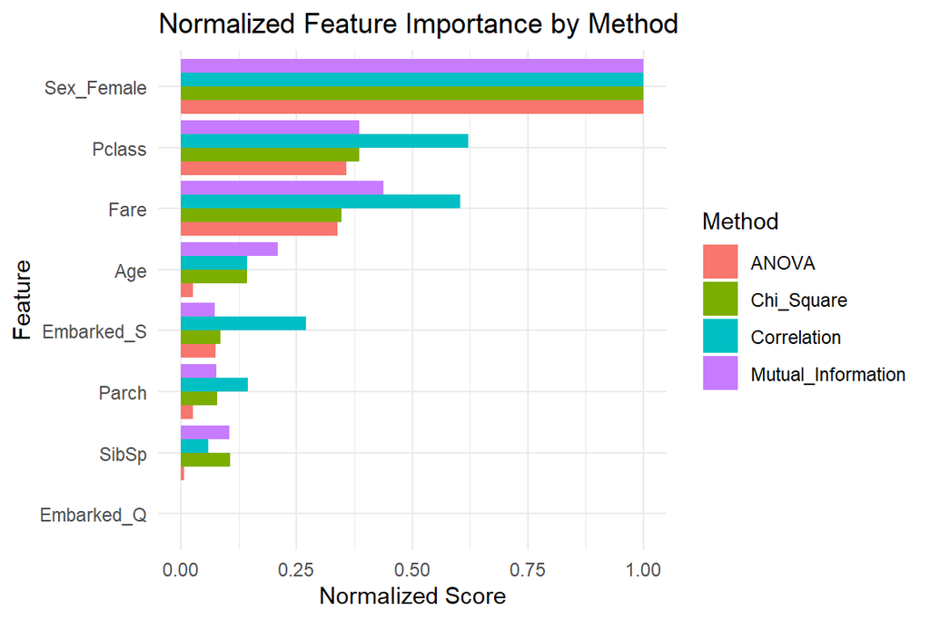

```r
# Combine scores into a summary table
feature_names <- names(titanic_train_scaled)[-1]  # exclude 'Survived'

# Correlation coefficients (absolute value for strength)
cor_scores <- abs(correlation_matrix["Survived", feature_names])

# Chi-square and ANOVA used p-values (lower is better, so take -log10 for comparability)
chi_scores <- -log10(chi_square_scores[feature_names])
anova_scores <- -log10(anova_results[feature_names])

# Mutual information already works as-is
mi_ordered <- mi_scores[feature_names]


feature_summary <- tibble(
  Feature = feature_names,
  Correlation = cor_scores,
  ANOVA = anova_scores,
  Chi_Square = chi_scores,
  Mutual_Information = mi_ordered
)

# Normalize each column (method) between 0 and 1 this is just so we see them represented `equal` in the graph.
normalized_summary <- feature_summary %>%
  mutate(across(-Feature, ~ (.x - min(.x)) / (max(.x) - min(.x))))


normalized_long <- normalized_summary %>%
  pivot_longer(cols = -Feature, names_to = "Method", values_to = "Score")

ggplot(normalized_long, aes(x = reorder(Feature, Score), y = Score, fill = Method)) +
  geom_col(position = "dodge") +
  coord_flip() +
  labs(title = "Normalized Feature Importance by Method",
       x = "Feature", y = "Normalized Score",
       fill = "Method") +
  theme_minimal()
```

```r
rm(list = c('mi_scores','normalized_long','normalized_summary','mi_ordered','mi_scores','chi_scores','anova_scores','cor_scores'))
```

Now we want to select the top 5 features:

```r
# Set how many top features to consider from each method
k <- 5

# Rank features per method (higher = more important)
ranked_features <- feature_summary %>%
  mutate(across(-Feature, ~ rank(-.x)))  # descending rank

# Count how often each feature appears in top k
top_k_counts <- ranked_features %>%
  mutate(across(-Feature, ~ .x <= k)) %>%
  mutate(Vote_Count = rowSums(across(-Feature))) %>%
  arrange(desc(Vote_Count))

top_k_counts
```

```
# A tibble: 8 × 6
  Feature    Correlation ANOVA Chi_Square Mutual_Information Vote_Count
  <chr>      <lgl>       <lgl> <lgl>      <lgl>                   <dbl>
1 Pclass     TRUE        TRUE  TRUE       TRUE                        4
2 Fare       TRUE        TRUE  TRUE       TRUE                        4
3 Sex_Female TRUE        TRUE  TRUE       TRUE                        4
4 Age        FALSE       FALSE TRUE       TRUE                        2
5 SibSp      FALSE       FALSE TRUE       TRUE                        2
6 Parch      TRUE        TRUE  FALSE      FALSE                       2
7 Embarked_S TRUE        TRUE  FALSE      FALSE                       2
8 Embarked_Q FALSE       FALSE FALSE      FALSE                       0
```

```r
rm(list = c('ranked_features','top_k_counts','feature_summary'))
```

Vote_Count indicates how many methods placed the feature in their top k.

Features with the highest count were consistently important across techniques.

```r
titanic_train_scaled <- titanic_train_scaled %>%
  select (-c('SibSp','Embarked_Q'))
```

# 3 Fitting the Logistic Regression Model

```r
# Fit logistic regression model
model <- glm(Survived ~ ., data = titanic_train_scaled, family = binomial)

# View summary of the model
summary(model)
```

```
Call:
glm(formula = Survived ~ ., family = binomial, data = titanic_train_scaled)

Coefficients:
            Estimate Std. Error z value             Pr(>|z|)
(Intercept)   2.0287     0.7785   2.606              0.00916 **
Pclass       -1.0806     0.1569  -6.887     0.00000000000568 ***
Age          -2.8279     0.6033  -4.687     0.00000276792324 ***
Parch        -1.4303     0.7440  -1.922              0.05457 .
Fare          0.1205     0.1363   0.884              0.37677
Sex_Female    2.6314     0.1949  13.500 < 0.0000000000000002 ***
Embarked_S   -0.4555     0.1986  -2.293              0.02184 *
---
Signif. codes:  0 '***' 0.001 '**' 0.01 '*' 0.05 '.' 0.1 ' ' 1

(Dispersion parameter for binomial family taken to be 1)

    Null deviance: 1186.66  on 890  degrees of freedom
Residual deviance:  794.19  on 884  degrees of freedom
AIC: 808.19

Number of Fisher Scoring iterations: 5
```

```r
# Get predicted probabilities on the training data
train_probs <- predict(model, type = "response")

# Convert to predicted classes
train_pred_classes <- ifelse(train_probs > 0.5, 1, 0)
```

For more information about how to interpret the results you can visit Classification problems

The confusion matrix with the results is

```r
train_conf <- table(Predicted = train_pred_classes, Actual = titanic_train_scaled$Survived)
train_conf
```

```
         Actual
Predicted   0   1
        0 465 100
        1  84 242
```

or using `caret`

```r
conf_train <- confusionMatrix(as.factor(train_pred_classes), as.factor(titanic_train_scaled$Survived))
conf_train
```

```
Confusion Matrix and Statistics

          Reference
Prediction   0   1
         0 465 100
         1  84 242

               Accuracy : 0.7935
                 95% CI : (0.7654, 0.8196)
    No Information Rate : 0.6162
    P-Value [Acc > NIR] : <0.0000000000000002

                  Kappa : 0.5595

 Mcnemar's Test P-Value : 0.2688

            Sensitivity : 0.8470
            Specificity : 0.7076
         Pos Pred Value : 0.8230
         Neg Pred Value : 0.7423
             Prevalence : 0.6162
         Detection Rate : 0.5219
   Detection Prevalence : 0.6341
      Balanced Accuracy : 0.7773

       'Positive' Class : 0
```

we will see in more detail how to interpret it a bit later.

## 3.1 Testing it with the test dataset

### 3.1.1 Preparing the data

To check how it is doing over the test data, we need to also drop the variables that we are not using in the model for this dataset and apply the same transformation that we did to the train dataset: Treat NAs

```r
summary(titanic_test)
```

```
  PassengerId         Pclass          Name               Sex
 Min.   : 892.0   Min.   :1.000   Length:418         Length:418
 1st Qu.: 996.2   1st Qu.:1.000   Class :character   Class :character
 Median :1100.5   Median :3.000   Mode  :character   Mode  :character
 Mean   :1100.5   Mean   :2.266
 3rd Qu.:1204.8   3rd Qu.:3.000
 Max.   :1309.0   Max.   :3.000

      Age            SibSp            Parch           Ticket
 Min.   : 0.17   Min.   :0.0000   Min.   :0.0000   Length:418
 1st Qu.:21.00   1st Qu.:0.0000   1st Qu.:0.0000   Class :character
 Median :27.00   Median :0.0000   Median :0.0000   Mode  :character
 Mean   :30.27   Mean   :0.4474   Mean   :0.3923
 3rd Qu.:39.00   3rd Qu.:1.0000   3rd Qu.:0.0000
 Max.   :76.00   Max.   :8.0000   Max.   :9.0000
 NA's   :86
      Fare            Cabin             Embarked            Survived
 Min.   :  0.000   Length:418         Length:418         Min.   :0.0000
 1st Qu.:  7.896   Class :character   Class :character   1st Qu.:0.0000
 Median : 14.454   Mode  :character   Mode  :character   Median :0.0000
 Mean   : 35.627                                         Mean   :0.3687
 3rd Qu.: 31.500                                         3rd Qu.:1.0000
 Max.   :512.329                                         Max.   :1.0000
 NA's   :1                                               NA's   :22
```

There are 22 rows without survival data. We will drop those rows as they will not help assessing the model. We will assign the average for the missing values in Age and Fare.

```r
# remove columns
titanic_test_reduced <- titanic_test_clean %>% select (-c(PassengerId,Name,SibSp,Ticket,Cabin))
#factor and create dummies
titanic_test_encoded <- titanic_test_reduced %>%
  mutate(
    Sex = factor(Sex, levels = c("male", "female"), labels = c("Male", "Female")),
    Embarked = as.factor(Embarked)
  ) %>%
  fastDummies::dummy_cols(
    select_columns = c("Sex", "Embarked"),
    remove_first_dummy = FALSE,
    remove_selected_columns = TRUE
  )
```

Note that we didn’t drop the columns this time when creating the dummies.

This is because remove_first_dummy = TRUE, removes the first value in the column, and in the test dataset it may not be the same as the train dataset, so we create them all and drop them manually.

```r
# Get the column names used for training (excluding Survived if needed)
train_features <- colnames(titanic_train_scaled)

# Select those same columns from the test set
titanic_test_encoded <- titanic_test_encoded[, train_features]
```

```r
#normalize variables
titanic_test_normalized <- titanic_test_encoded %>%
  mutate(
    Age = (Age - min(Age)) / (max(Age) - min(Age)),
    Parch = (Parch - min(Parch)) / (max(Parch) - min(Parch)),
    Fare =  log1p(Fare)
  )
rm(titanic_test_encoded)
```

### 3.1.2 Predicting survival

Now we apply the model to the dataset and see how many classifications it got right from each class using a Table

```r
# Predict on the test set (assuming titanic_test_normalized is prepared similarly)
pred_probs <- predict(model, newdata = titanic_test_normalized, type = "response")

# Convert probabilities to class predictions (threshold = 0.5)
pred_classes <- ifelse(pred_probs >= 0.5, 1, 0)

# Create confusion matrix
t <- table(Predicted = pred_classes,
  Actual = titanic_test_normalized$Survived)


# Render the nicely styled table
kable(t, format = "html", caption = "Confusion Matrix: Survival Status") %>%
  kable_styling(bootstrap_options = c("striped", "hover", "condensed"), full_width = F) %>%
  column_spec(1:ncol(t), width = "100px") %>%
  add_header_above(c("Predicted" = 1, "Actual" = 2))
```

Confusion Matrix: Survival Status

| Predicted | Actual 0 | Actual 1 |
| --- | --- | --- |
| 0 | 202 | 47 |
| 1 | 48 | 99 |

## 3.2 How to interpret the results:

### 3.2.1 Model Accuracy

Proportion of total predictions that are correct.

The model has an accuracy of ~76%, meaning it correctly predicted about three out of four passengers.

### 3.2.2 Precision

Out of the passengers predicted as survivors, how many truly survived?

$$\text{Precision} = \frac{TP}{TP+FP}= \frac{99}{99+48}= \frac{99}{147} = 0.673$$

Precision is about 67%, which means that when your model predicts survival, it’s correct 2 out of 3 times.

**Note**

Quick Tips for Interpretation Accuracy is useful when classes are balanced—but Titanic data isn’t entirely balanced.

Precision is crucial when false positives are costly (e.g., medical diagnosis or fraud detection).

You might also want to look at missclassification

Recall (sensitivity):
$$\frac{TP}{TP + FN} = \frac{99}{99 + 47} \approx 0.678$$

we can also use the `caret` package to create a confusion matrix and get a summary of the results. Here we show the new confusion matrix results from the test dataset on the left with the confusion matrix from the train dataset on the right.

```r
# Define the common levels, based on what Survived should be (e.g. 0 and 1)
common_levels <- levels(factor(titanic_test_normalized$Survived))

# Ensure both vectors use the same levels
# Define the common levels, based on what Survived should be (e.g. 0 and 1)
common_levels <- levels(factor(titanic_test_normalized$Survived))
pred_classes_factor <- factor(pred_classes, levels = common_levels)
true_classes_factor <- factor(titanic_test_normalized$Survived, levels = common_levels)

# Now call confusionMatrix
conf_test<- caret::confusionMatrix(pred_classes_factor, true_classes_factor)
conf_test
conf_train
rm(list = c('common_levels','pred_classes_factor','true_classes_factor'))
```

```
Confusion Matrix and Statistics

          Reference
Prediction   0   1
         0 202  47
         1  48  99

               Accuracy : 0.7601
                 95% CI : (0.7149, 0.8013)
    No Information Rate : 0.6313
    P-Value [Acc > NIR] : 0.0000000289

                  Kappa : 0.4854

 Mcnemar's Test P-Value : 1

            Sensitivity : 0.8080
            Specificity : 0.6781
         Pos Pred Value : 0.8112
         Neg Pred Value : 0.6735
             Prevalence : 0.6313
         Detection Rate : 0.5101
   Detection Prevalence : 0.6288
      Balanced Accuracy : 0.7430

       'Positive' Class : 0
```

```
Confusion Matrix and Statistics

          Reference
Prediction   0   1
         0 465 100
         1  84 242

               Accuracy : 0.7935
                 95% CI : (0.7654, 0.8196)
    No Information Rate : 0.6162
    P-Value [Acc > NIR] : <0.0000000000000002

                  Kappa : 0.5595

 Mcnemar's Test P-Value : 0.2688

            Sensitivity : 0.8470
            Specificity : 0.7076
         Pos Pred Value : 0.8230
         Neg Pred Value : 0.7423
             Prevalence : 0.6162
         Detection Rate : 0.5219
   Detection Prevalence : 0.6341
      Balanced Accuracy : 0.7773

       'Positive' Class : 0
```

There’s detailed information on how to interpret these results in confusion matrix

we can also get the summary:

```r
# Extract metrics
overall <- conf_test$overall
byClass <- conf_test$byClass

# Combine into a data frame
cm_summary <- data.frame(
  Metric = c("Accuracy", "Kappa", "Sensitivity", "Specificity",
             "Precision", "Recall", "F1"),
  Value = c(
    round(overall["Accuracy"], 3),
    round(overall["Kappa"], 3),
    round(byClass["Sensitivity"], 3),
    round(byClass["Specificity"], 3),
    round(byClass["Pos Pred Value"], 3),  # Precision
    round(byClass["Sensitivity"], 3),     # Recall
    round(byClass["F1"], 3)
  )
)

knitr::kable(cm_summary, caption = "Confusion Matrix Performance Summary", format = "markdown") %>%
   column_spec(1:ncol(t), width = "150px") %>%

rm(overall)
rm(byClass)
rm(cm_summary)
```

[output not shown]

### 3.2.3 ROC Curve (Receiver Operating Characteristic)

We can adjust a ROC curve. This plot helps you visualize the trade-off between true positive rate (recall) and false positive rate across different thresholds.

The ROC Curve will show how well your model separates the classes. If your AUC (Area Under Curve) is close to 1, your model’s on point; near 0.5, it’s not so great.

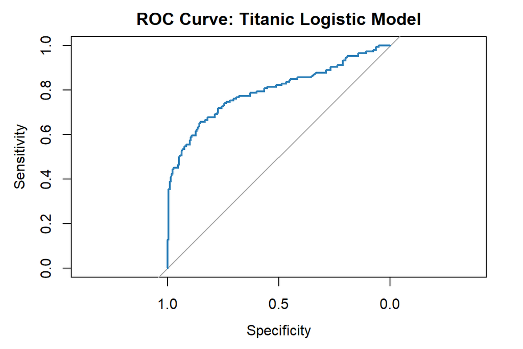

```r
# Generate ROC curve
roc_obj <- roc(titanic_test_normalized$Survived, pred_probs)
plot(roc_obj, main = "ROC Curve: Titanic Logistic Model", col = "#2c7fb8", lwd = 2)
```

```r
# AUC value
auc(roc_obj)
```

```
Area under the curve: 0.7971
```

### 3.2.4 Precision-Recall Curve

The Precision-Recall (PR) Curve is a diagnostic tool used to evaluate the performance of classification models, especially when dealing with imbalanced datasets (like survival prediction where fewer people survive).

Curve Mechanics: You vary the classification threshold (e.g., from 0 to 1) and compute precision & recall at each step.

The curve shows the trade-off:

High precision often means lower recall, and viceversa.

The ideal model has both high precision and recall, but that’s rare — so we look for a good balance. Models that handle class imbalance well will maintain higher area under the PR curve (AUC-PR).

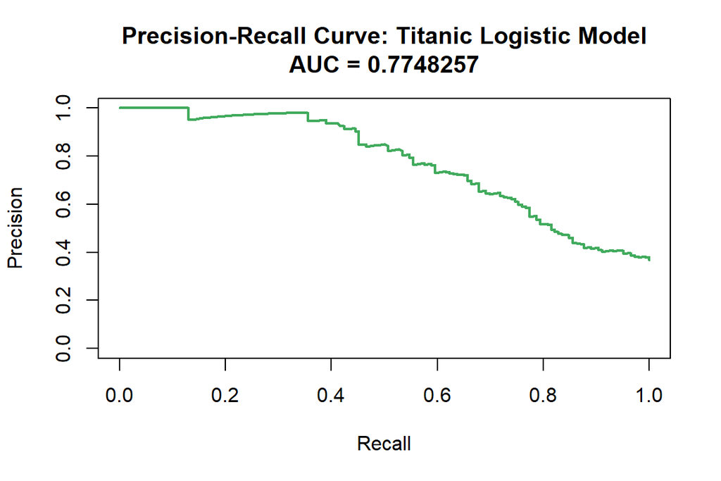

```r
library(PRROC)
pr_obj <- PRROC::pr.curve(scores.class0 = pred_probs[titanic_test_normalized$Survived == 1],
                   scores.class1 = pred_probs[titanic_test_normalized$Survived == 0],
                   curve = TRUE)

plot(pr_obj, main = "Precision-Recall Curve: Titanic Logistic Model", col = "#41ab5d", lwd = 2)
```

Unlike ROC curves—which track true vs false positive rates—the PR curve focuses more tightly on the model’s performance for the positive class (in this case, passengers who survived).

- Precision = True Positives / (True Positives + False Positives) → Of all predicted positives, how many are actual positives? How cleanly we predicted survivors without mixing in false positives.
- Recall = True Positives / (True Positives + False Negatives) → Of all actual positives, how many did we correctly predict?

**Interpreting the Curve’s Shape** If the curve hugs the top right corner, your model nails both precision and recall

If the curve drops off fast, it means the model struggles either with finding actual survivors or is overpredicting survival, diluting precision.

A flat curve near the bottom suggests predictions for survivors are mostly wrong—or barely better than random guessing.

**Area Under the Curve (AUC-PR)** If you retrieved the AUC score from pr_obj, that would quantify the curve’s strength. AUC-PR close to 1.0 means excellent predictive quality. Around 0.5 means “meh,” and lower values suggest your model’s having a rough time.

From this graph, you’re able to:

Visualize the trade-off: At higher recall, precision may drop—because you’re casting a wider net.

Fine-tune thresholds: This guides you in choosing a threshold that balances precision vs recall based on what matters most (e.g., in healthcare you might prioritize recall; in fraud detection, precision). Plot precision vs. recall using ggplot2, PRROC, or precrec packages.

Annotate optimal threshold points using the F1 score:
$$F1 = 2 \cdot \frac{{\text{Precision} \cdot \text{Recall}}}{{\text{Precision} + \text{Recall}}}$$

Tune your logistic regression decision boundary to maximize F1 or balance precision-recall, rather than defaulting to 0.5.

### 3.2.5 Test vs Train results

Let’s see a few ways of comparing how our model is doing in the training vs the test dataset:

#### Predicted vs actual survival stacked bar plot

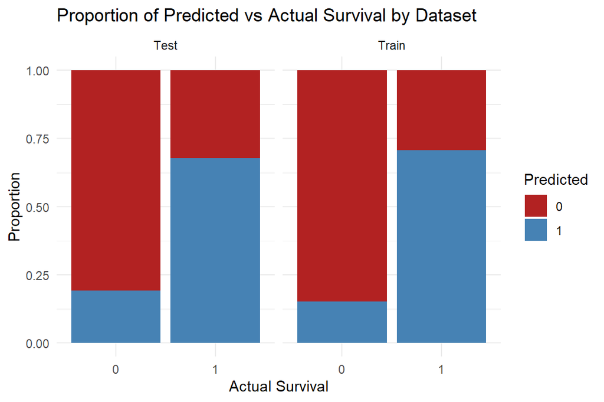

```r
# Prepare data frames with predictions and actuals
train_df <- data.frame(
  Actual = titanic_train_scaled$Survived,
  Predicted = train_pred_classes,  # predictions from training set
  Set = "Train"
)

test_df <- data.frame(
  Actual = titanic_test_normalized$Survived,
  Predicted = pred_classes,  # predictions from test set
  Set = "Test"
)

# Combine for plotting
combined_df <- bind_rows(train_df, test_df)

ggplot(combined_df, aes(x = as.factor(Actual), fill = as.factor(Predicted))) +
  geom_bar(position = "fill") +
  facet_wrap(~Set) +
  labs(
    title = "Proportion of Predicted vs Actual Survival by Dataset",
    x = "Actual Survival",
    y = "Proportion",
    fill = "Predicted"
  ) +
  scale_fill_manual(values = c("firebrick", "steelblue")) +
  theme_minimal()
```

#### Confusion Matrix Heatmaps

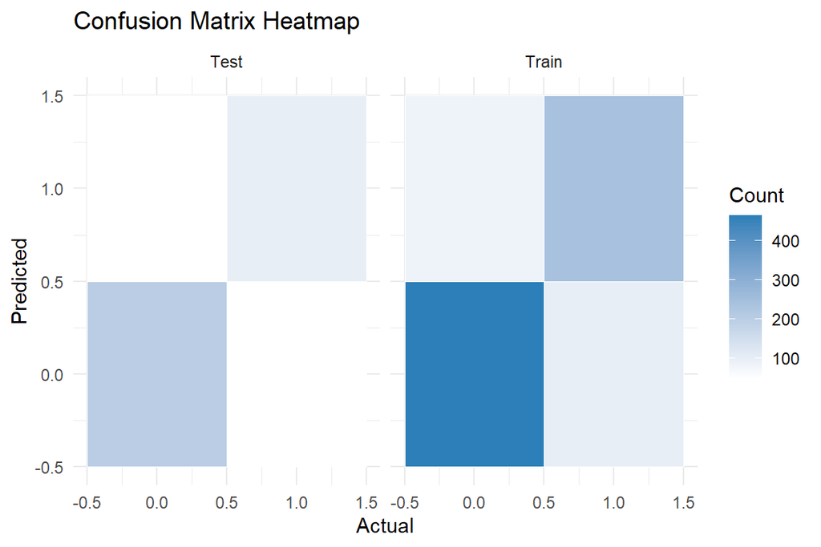

```r
library(reshape2)

# Create confusion matrices
train_mat <- table(Predicted = train_pred_classes, Actual = titanic_train_scaled$Survived)
test_mat <- table(Predicted = pred_classes, Actual = titanic_test_normalized$Survived)

# Convert to data frame for plotting
train_melt <- melt(train_mat)
train_melt$Set <- "Train"
test_melt <- melt(test_mat)
test_melt$Set <- "Test"

conf_df <- bind_rows(train_melt, test_melt)

ggplot(conf_df, aes(x = Actual, y = Predicted, fill = value)) +
  geom_tile(color = "white") +
  facet_wrap(~Set) +
  scale_fill_gradient(low = "white", high = "#2c7fb8") +
  labs(title = "Confusion Matrix Heatmap", fill = "Count") +
  theme_minimal()
```

#### Performance Metrics Comparison Plot

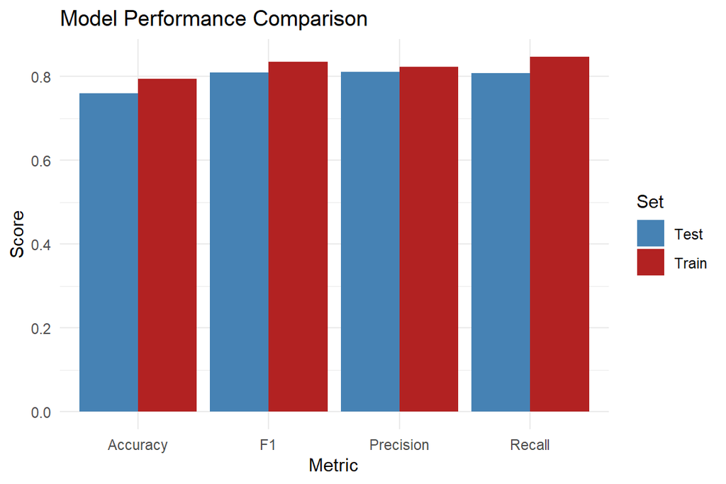

```r
library(caret)
# Example using confusionMatrix()
conf_train <- confusionMatrix(as.factor(train_pred_classes), as.factor(titanic_train_scaled$Survived))
conf_test  <- confusionMatrix(as.factor(pred_classes), as.factor(titanic_test_normalized$Survived))

metrics_df <- data.frame(
  Metric = c("Accuracy", "Precision", "Recall", "F1"),
  Train = c(conf_train$overall["Accuracy"],
            conf_train$byClass["Precision"],
            conf_train$byClass["Recall"],
            conf_train$byClass["F1"]),
  Test = c(conf_test$overall["Accuracy"],
           conf_test$byClass["Precision"],
           conf_test$byClass["Recall"],
           conf_test$byClass["F1"])
)

metrics_long <- metrics_df %>%
  pivot_longer(-Metric, names_to = "Set", values_to = "Score")

ggplot(metrics_long, aes(x = Metric, y = Score, fill = Set)) +
  geom_col(position = "dodge") +
  labs(title = "Model Performance Comparison", y = "Score", x = "Metric") +
  scale_fill_manual(values = c("steelblue", "firebrick")) +
  theme_minimal()
```

### 3.2.6 Threshold Optimization for F1 Score

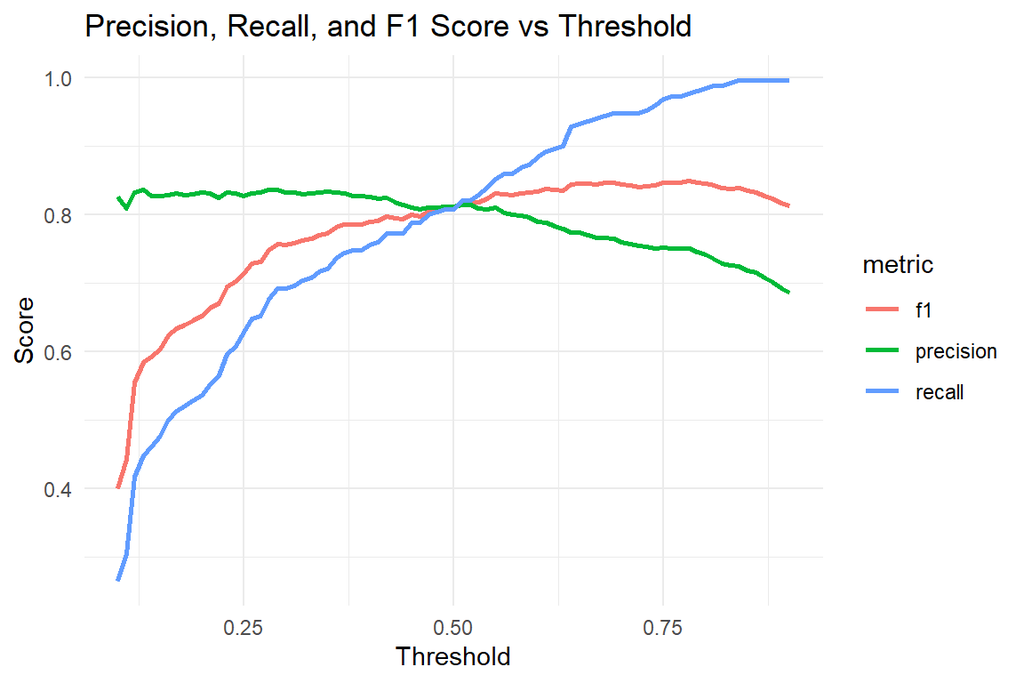

```r
library(yardstick)
library(dplyr)

# Prepare ground truth and predicted probabilities
truth <- factor(titanic_test_normalized$Survived, levels = c(0, 1))
estimate <- pred_probs

# Define threshold sequence
thresholds <- seq(0.1, 0.9, by = 0.01)

# Function to compute precision, recall, F1 for each threshold
evaluate_threshold <- function(thresh) {

  pred <- factor(ifelse(estimate > thresh, 1, 0), levels = c(0, 1))

  classified <- data.frame(truth = truth, pred = pred)

  precision_val <- precision(classified, truth = truth, estimate = pred)$.estimate
  recall_val <- recall(classified, truth = truth, estimate = pred)$.estimate
  f1_val <- f_meas(classified, truth = truth, estimate = pred)$.estimate

  return(c(precision = precision_val, recall = recall_val, f1 = f1_val))
}

# Use sapply to apply across all thresholds
scores <- t(sapply(thresholds, evaluate_threshold))

# Convert to data frame with proper labels
metric_df <- data.frame(threshold = thresholds, scores)

metrics_long <- metric_df %>%
  pivot_longer(cols = -threshold, names_to = "metric", values_to = "score")

ggplot(metrics_long, aes(x = threshold, y = score, color = metric)) +
  geom_line(size = 1) +
  labs(title = "Precision, Recall, and F1 Score vs Threshold",
       x = "Threshold", y = "Score") +
  theme_minimal()
```